# tmpz8j82e7f

**Principal Component Analysis (PCA)**

**1. The What?**

- Principal Component Analysis (PCA) is a **linear** **dimensionality reduction** technique that is widely used to reduce the dimensionality of high dimensional data, by transforming it into a lower dimensional one that still retains most of the information in the original data.
- Reducing the dimensionality of a data set naturally comes at the expense of accuracy, but the trick in dimensionality reduction is to trade minimal little accuracy for simplicity. Because smaller data sets are easier to explore and visualize, and less computationally demanding, it makes data analysis much easier and faster for machine learning models.

2. Mathematical Foundation and Methodology-  
2.1 Core Algorithm and Implementation

- The algorithm begins with data standardization, where features are centered around zero mean and scaled to unit variance to ensure equal contribution from all variables. This preprocessing step is crucial because PCA is highly sensitive to the scale of variables, and features with larger ranges would otherwise dominate the analysis.
- The mathematical foundation rests on eigen decomposition of the covariance matrix. After standardization, the covariance matrix is computed to understand relationships between variables. The covariance matrix captures how variables change together, with positive values indicating variables that increase or decrease together, and negative values suggesting inverse relationships.
- The critical step involves calculating eigenvectors and eigenvalues from the covariance matrix. Eigenvectors represent the directions of maximum variance in the data, while eigenvalues quantify the amount of variance captured along each direction. These eigenvectors become the principal components, and their corresponding eigenvalues determine their importance in explaining the dataset's variance.
  2. **Important Ideas**

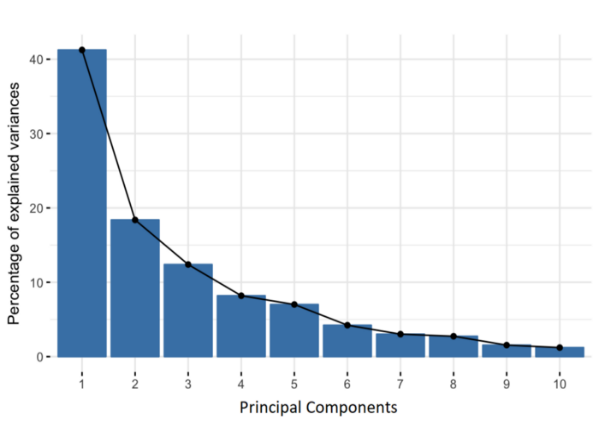

- **Principal Components-** Principal components are new variables that are constructed as linear combinations or mixtures of the initial variables. These combinations are done such that the new variables (i.e., principal components) are uncorrelated (geometrically, all the principal component axes are mutually perpendicular) and most of the information in the initial data is compressed into the first few components. So, the idea is 10-dimensional data gives you 10 principal components, but PCA tries to compress the most of the information into the first principal component, then the second and so on, resembling something like shown in the scree plot.
- **Construction of Principal Components-** The first principal component has most of the information. We start by constructing a multi-dimensional line passing through the origin, represented by $y = Mx$ where $x$ represents the vector of dimension equal to the dimensions of original data and $M$ represent the “slopes” with respect to each of these dimensions. We gradually change the slopes to find a **best fit** line where the projection of data has the **maximum variance**, i.e. is most widely spread. This gives the PC1 or the first principal component. PC2, PC3, etc. are determined similarly with the additional condition that it is uncorrelated to any of the other principal components, i.e. they are **mutually perpendicular**.

2. **Step-by-Step procedure**

The complete PCA algorithm follows these sequential steps:

1. **Data Standardization**: Transform features to have zero mean and unit variance using Z-score normalization$\ z = \frac{x - \mu}{\sigma}$ [x ≡ data point; $\mu$ ≡ mean along some dimension; $\sigma$ ≡ standard deviation along same dimension]  
   The aim of this step is to standardize the range of the continuous initial variables so that each one of them contributes equally to the analysis. Large difference in ranges can cause unnecessary bias.
2. **Covariance Matrix Computation**: Calculate the covariance matrix to identify variable relationships. If **positive** then: the two variables increase or decrease together (**correlated**). If **negative** then: one increases when the other decreases (**Inversely correlated**)

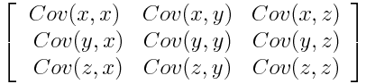

> The covariance matrix is a *p* × *p* symmetric matrix (where *p* is the number of dimensions) that has as entries the covariances associated with all possible pairs of the initial variables. For example, for a 3-dimensional data set with 3 variables *x*, *y*, and *z*, the covariance matrix is a 3×3 data matrix of this from:

> **Formula for Covariance:**  
> $cov(x,y) = \frac{\sum\lbrack(x_{i} - \overline{x})(y_{i} - \overline{y}))\rbrack}{(n - 1)}$ [$x_{i}\$and$\ y_{i}$ are individual data points for features $x$ and $y$ respectively; $\overline{x}\$and$\overline{\ y}$ are the means of features $x$ and $y$ respectively; $n$ is the number of data points.]
3. **Eigen decomposition**: Compute eigenvectors and eigenvalues from the covariance matrix. The eigenvectors represent the direction of maximum variance or “entropy” and hence represent the Principal Components. Eigenvalues represent the actual variance in data along these eigenvectors. **Eigenvalues are the variance of projected points along the corresponding eigenvector.**
4. **Component Selection**: Sort eigenvalues in descending order and select the top k components and label them as PC1, PC2…. PCk. The value of ‘k’ is generally taken as 2
5. **Transformation Matrix Construction (Feature Vector)**: Create the projection matrix from selected eigenvectors. This Feature Vector (**W**) is simply a matrix that has as columns the eigenvectors of the components that we decide to keep. This makes it the first step towards dimensionality reduction, because if we choose to keep only **k** eigenvectors (components) out of **k**, the final data set will have only **k** dimensions.
6. **Data Transformation**: Project original data onto the new component space. The mathematical representation of this transformation can be expressed as $y = XW^{t}$

**3. Scikit-learn Code Implementation**

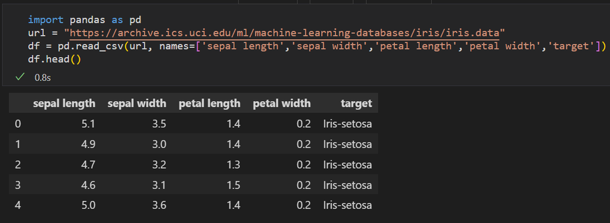

**3.1 Loading the Data – multi-dimensional (4) data**

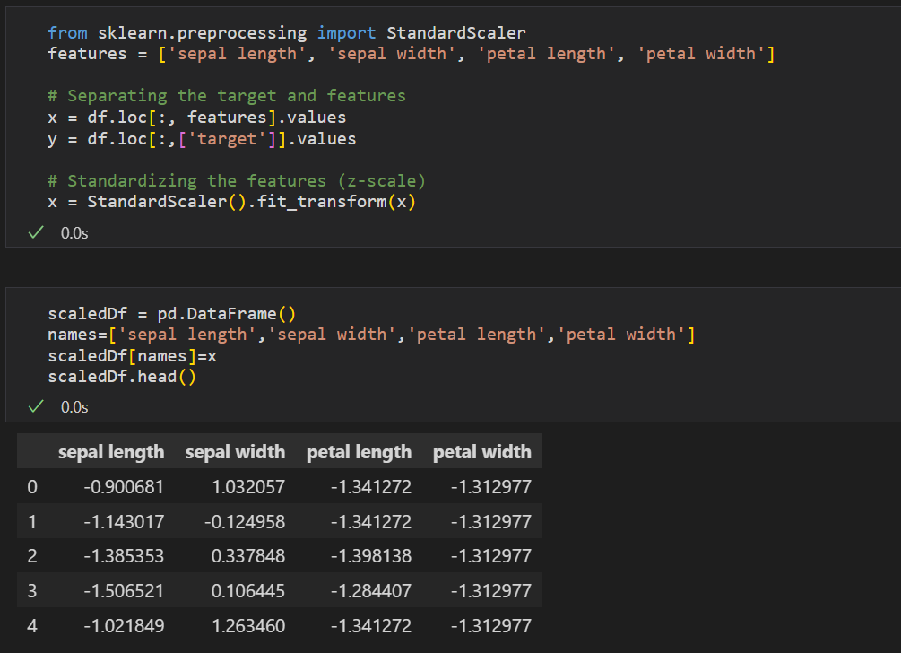

**3.2 Z-Score Normalization – after scaling**

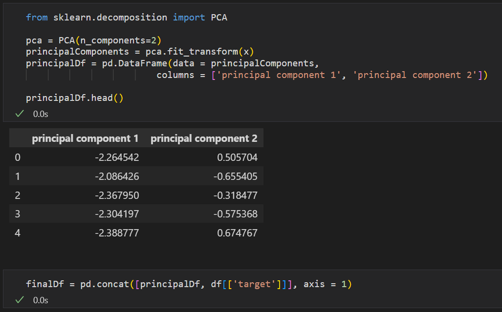

**3.3 PCA – after scaling down to 2 principal components**

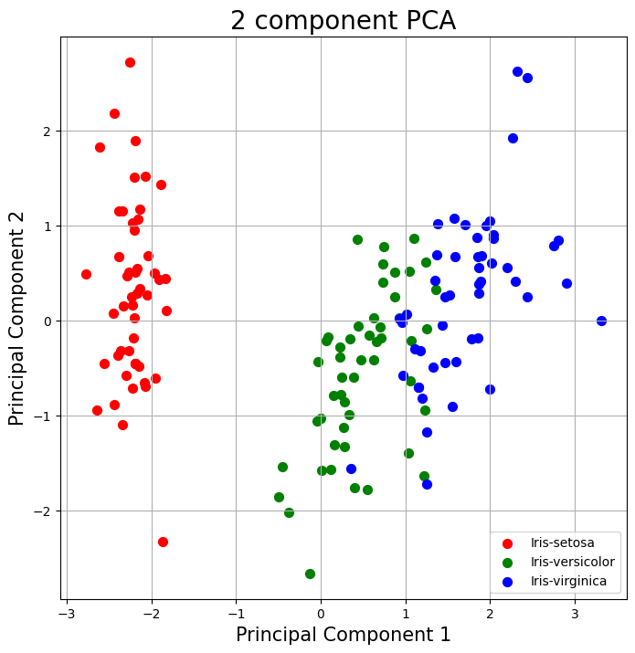

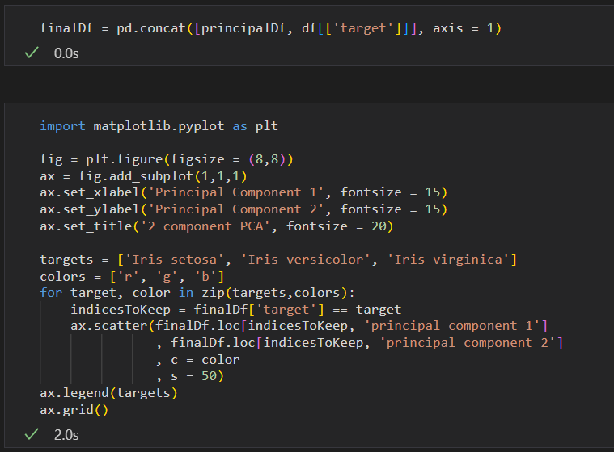

**3.4 Plotting using 2 principal components**

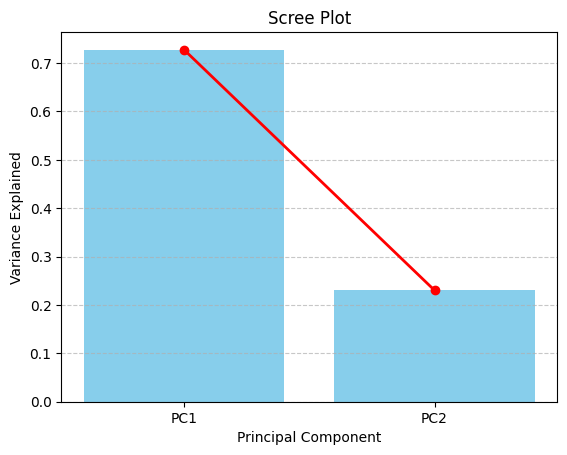

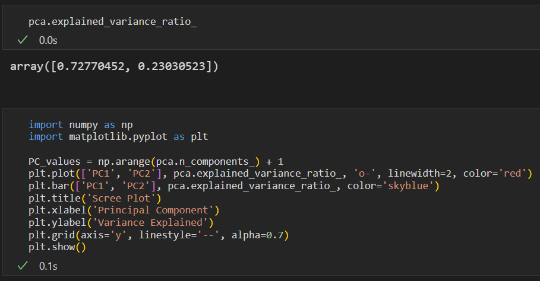

**3.5 Variance analysis and Scree plot**

**4. Utility and Limitations**

- PCA offers several compelling advantages that make it a preferred dimensionality reduction technique. It effectively reduces computational complexity while preserving the maximum amount of variance possible in the reduced space. The technique eliminates multicollinearity by creating orthogonal components, which improves the stability and interpretability of subsequent analyses. The method's ability to provide clear quantitative measures of information retention through explained variance ratios enables data scientists to make informed decisions about dimensionality reduction trade-offs. Additionally, PCA's deterministic nature ensures reproducible results, unlike some stochastic dimensionality reduction methods.
- **Image Recognition**, **DNA Analysis**, and **Stock Market Analysis** are some domains where PCA is often used to reduce the large amount of data into meaningful components while retaining maximum accuracy.
- Despite its strengths, PCA has several important limitations that users must consider. The technique assumes linear relationships between variables and may fail to capture complex nonlinear patterns in the data. This limitation has led to the development of kernel PCA, which extends the method to handle nonlinear relationships through kernel functions.
- PCA's sensitivity to data scaling requires careful preprocessing, as unstandardized data can produce misleading results. The method also suffers from reduced interpretability, as principal components represent linear combinations of original variables rather than meaningful physical quantities. This mathematical abstraction can make it challenging to explain results to stakeholders who require intuitive understanding of the underlying factors.
- Furthermore, PCA may not be suitable for all types of data, particularly sparse datasets or those with categorical variables that don't follow the linear assumptions underlying the technique. The computational complexity can become prohibitive for extremely high-dimensional data, requiring considerable processing time and resources.

-------------------------------------------------------------------------------------------------------------------------------------

1. https://builtin.com/data-science/step-step-explanation-principal-component-analysis
2. https://youtu.be/FgakZw6K1QQ?si=PcSD9c8_rbYEX08m (StatQuest with Josh Starmer)